# Visualization of Weather Data (Midwest)

Lorenz Menendez

03/06/2020

Before examining the data at the county level, it’s helpful to get an understanding for large regional trends in weather and pollution levels. this helps us situate the Chicagoland data in context of it’s larger spatial environment. The maps below take data measured at a variety of monitoring sensors to interpolate the value of temperature, pressure, windspeed, PM2.5 concetrations, and others across the Midwest. We find that many of the weather variables vary in predictable ways, which confirms that our data source has accurate data and that our interpolation method delivers coherent results given this data. But, there are also a few complicated trends in certain variables. We’ll explore these trends and discuss their meaning, possible origins, and implications for the project.

The following maps have a resolution of 10km to simplify visualization, however we use 1km and 250m grids in our modeling. We marked the Chicago area on these maps for reference.

# Temperature

Areas in Red represent relatively higher temperatures, while areas in Blue represent colder temperatures.

[figure not shown]

As expected, temperature has a considerable seasonal variation across all parts of the Midwest. Each month of the year brings a large change in average temperatures. January tends to be the height of Winter, with cold average temperatures, which a gentle warming trends across all areas until April, where thers an abrupt shift to warmer temperatures starting in May. High temps continue until September, when there’s an abrupt drop back to winter temperatures.

Spatially, we notice that Northern areas *always* have colder temperature relative to southern areas. Thanks to the lack of major topological features in the Midwest, the temperature gradient is relatively constant across all months. This is an important trend for us, since we can incorporate this recurring spatial trend in our models.

# Pressure

Areas in Red are low pressure areas while areas in Blue represent higher pressures.

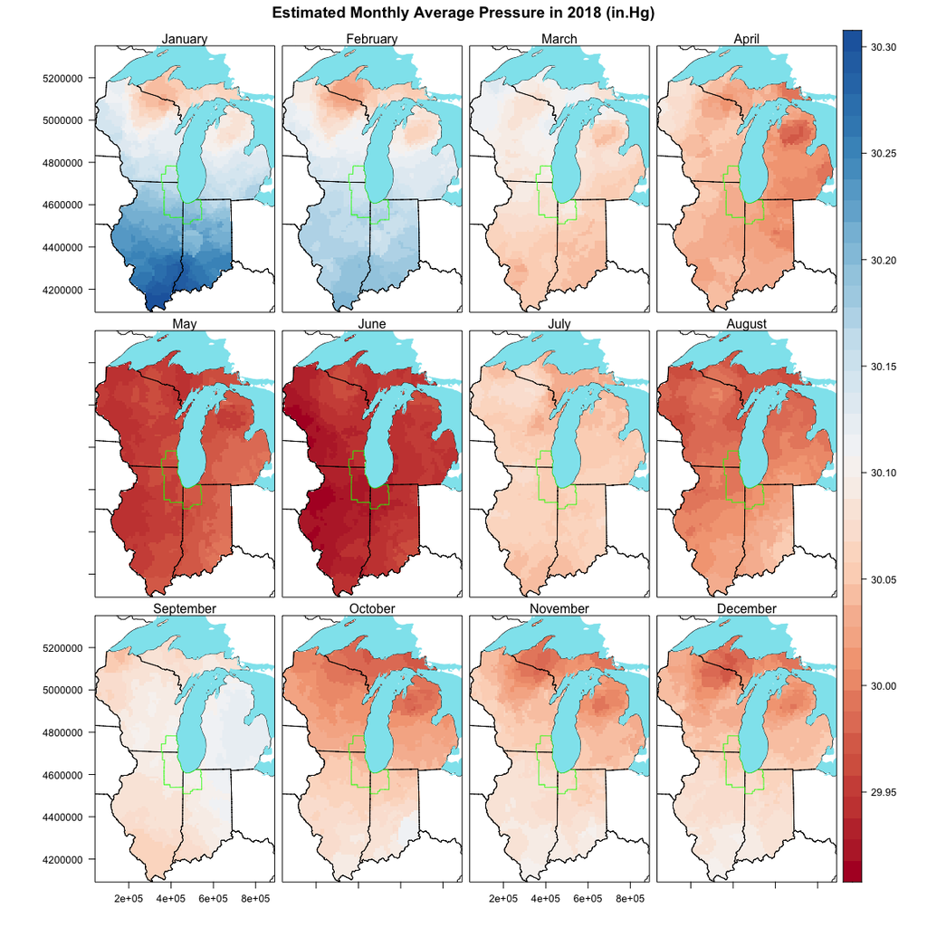

Pressure again varies heavily by season. Highest pressures are measured during the coldest winter months, when the air is cold and dense. Lowest pressures are measured during the beginning of the summer in May and June. This variation is very pronounced across Indiana, Illinois, and Southern Wisconsin. In the northern latitudes, pressures does not seem to vary as heavily. Similarly, the coldest months have a high spatial variability in pressure (see Northern Wisconsin and Michigan’s Upper Peninsula in January and February).

# Windspeed

Areas in dark red have high windspeeds while areas in yellow have low windspeeds.

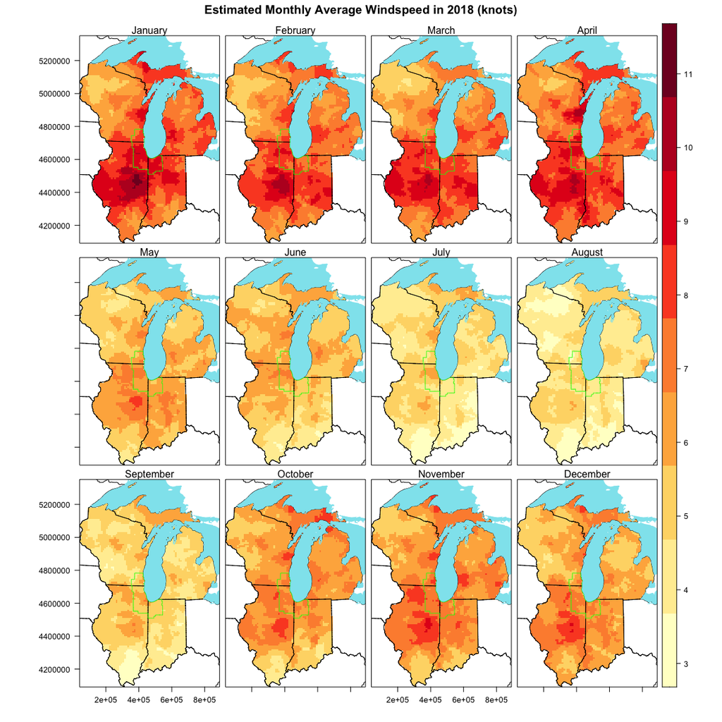

# Visibility

Areas in dark colors have lower average visibilities, areas in light have higher visibilities. Low visibility could be caused by clouds cover, mist, fog, steam, haze, among other possibilities. Note that the maximum visibility measured by the instrument is 10 statute miles, even if actual visibility is greather than 10 miles. Therefore, these maps tend to show lower average visibilities than if the sensors recorded visibiblites greater than 10 miles.

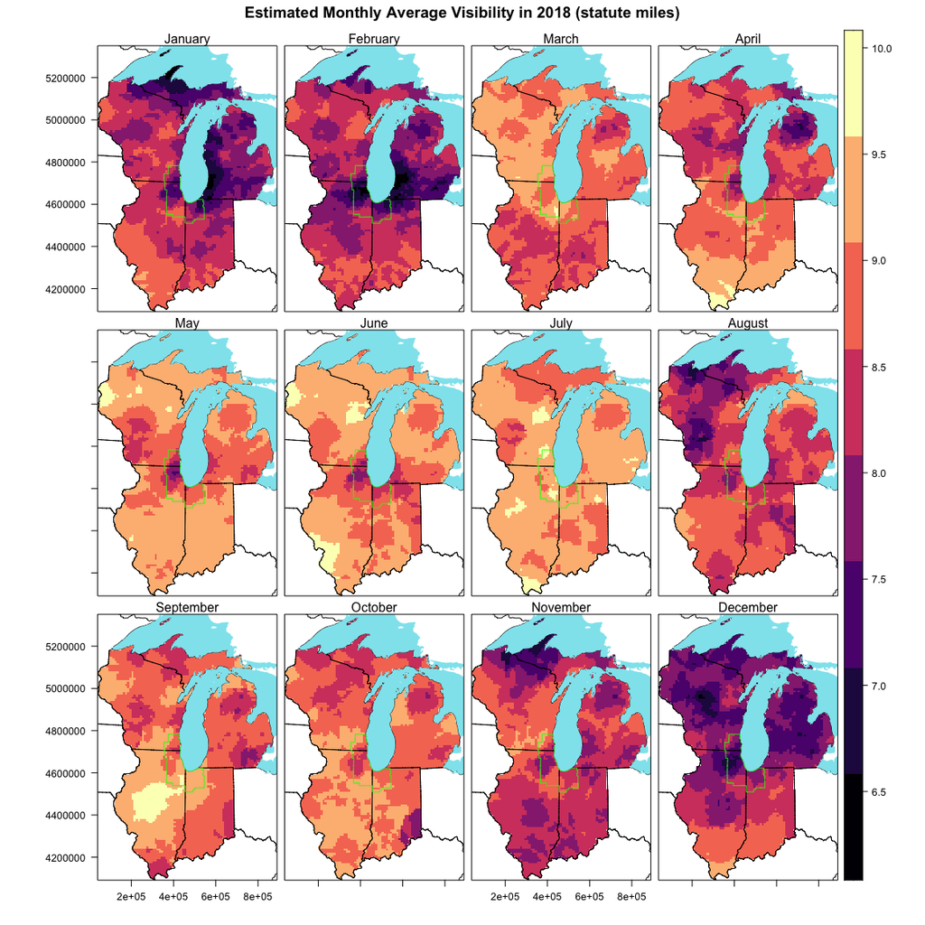

Visibilities dip in winter, when cloudy days becomes the norm and other precipitation limits visibility. The lowest visibilities are concentrated around Lake Michigan and the surrounding areas, as well as the northern latitudes. In certain months, we notice that visibility around Chicago does tend to be slightly lower relative to the surrounding area for many months. This is especially noticeable in May and June, where Chicago has the lowest average visibilities of the entire study area. Could this be a sign of high pollution? It’s debateable since we don’t see this phenomenon replaicted as much in other major Midwestern cities, like Milwaukee.

# Relative Humidity

The areas with high humidity are represented in blbue, while areas with low humidity are in green and yellow.

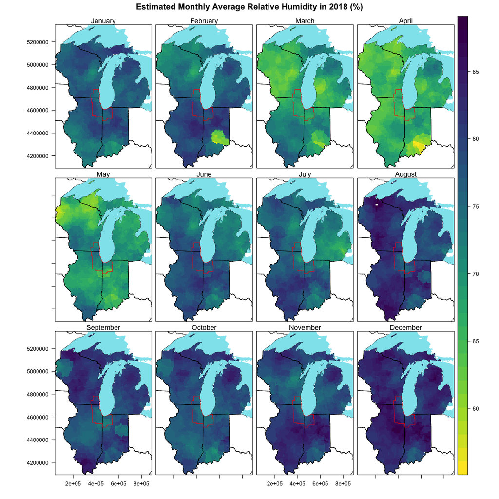

Within each month, there’s a lot of variability when it comes to relative humidity, even when averaging the data at a monthly scale. Relative humidity is unique from the other variables in that it is depends on a multitude of weather factors including temperature, pressure, and stability of the air. The combination of these factors seems to be very significantly from local area to local area.

# PM2.5 Concentration

Red areas are areas with relatively high PM2.5 concentration, while areas in Yellow show relatively low PM2.5 concetrations. We anticipate that the spatial accuracy of this map is lower compared to the rest of the weather variables because this data was collected from a fewer number of EPA sensors.

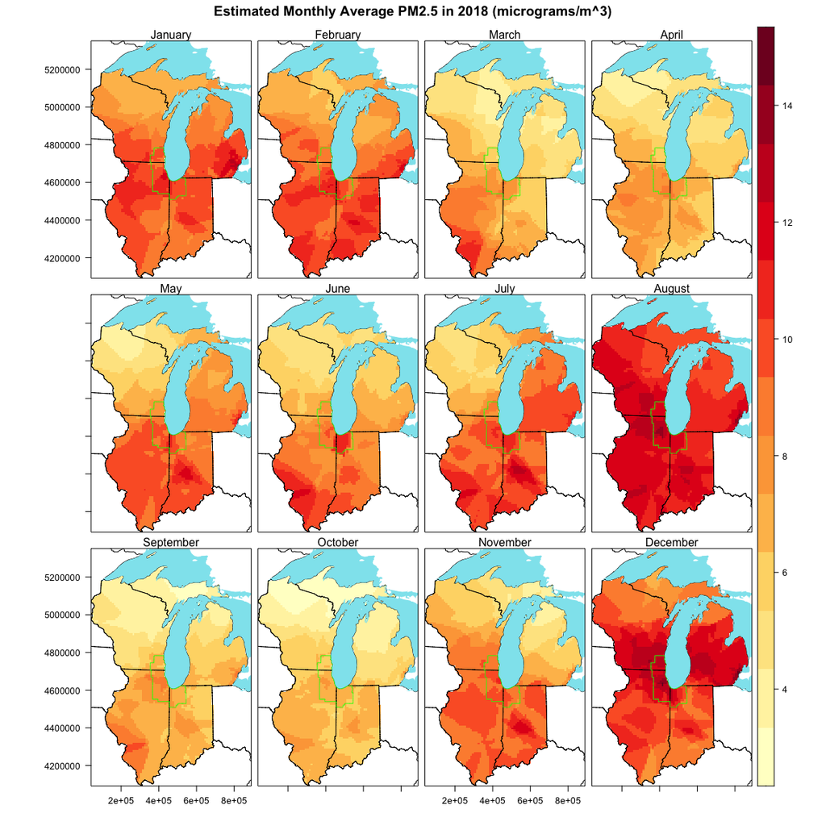

In terms of the spatial distribution, Illinois and Indiana tend to have higher amount of pollution across most months compared to Wisconsin and Northern Michigan, most likely since most of the major cities and population live in the Southern areas compared to northern Wisconsin and the Upper Peninsula of Michigan.